# Analyse des Combats de MMA dans l’UFC

#### Visualisation 2 : Analyse des différences stratégiques entre les gagnants et les perdants

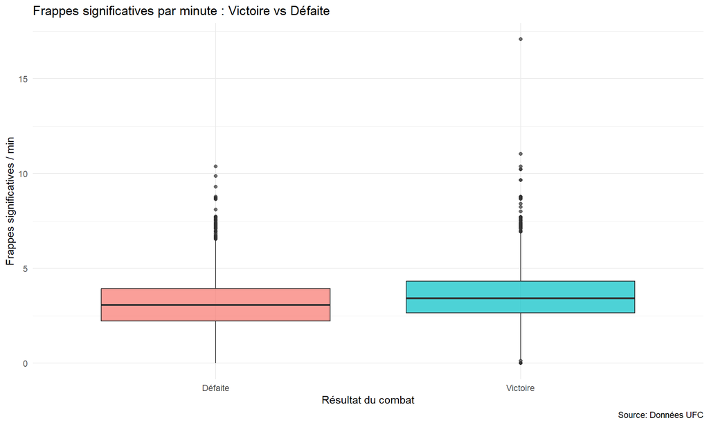

**Interprétation :** Les vainqueurs envoient généralement plus de frappes significatives par minute que les perdants. Cela suggère qu’un style offensif, basé sur l’activité en striking, est souvent associé à une plus grande probabilité de victoire.

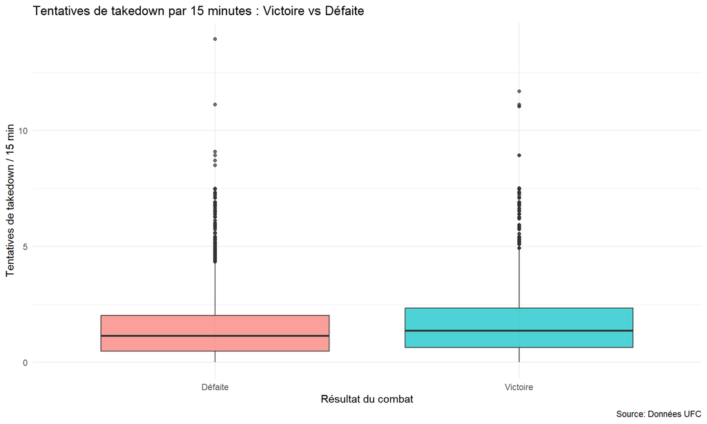

**Interprétation :** Les gagnants ont, en moyenne, un volume légèrement supérieur de tentatives de takedown. Bien que moins flagrant que pour les frappes, cela montre que les compétences en lutte peuvent jouer un rôle déterminant, notamment en contrôle du combat au sol.

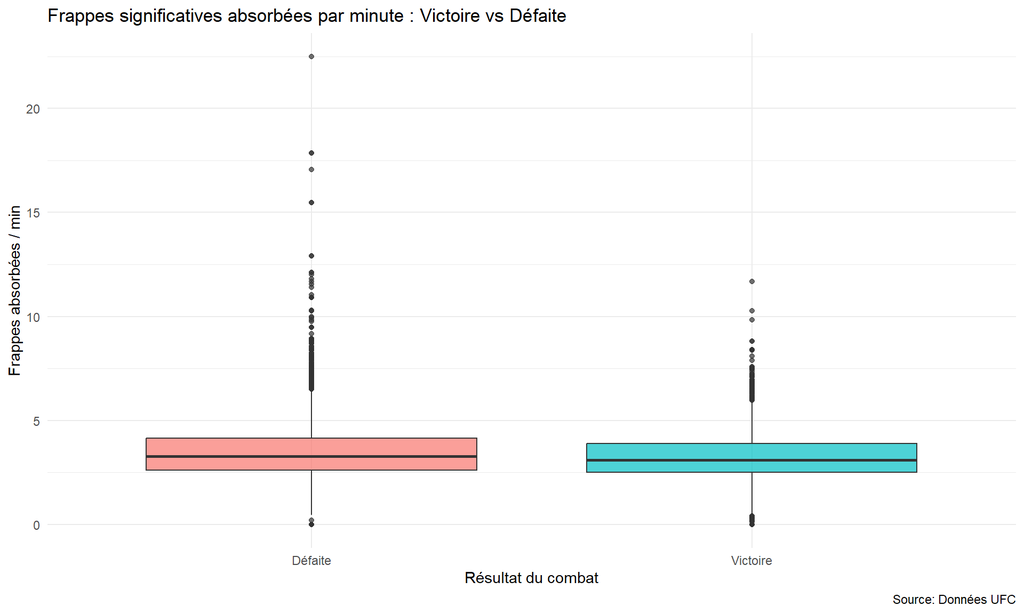

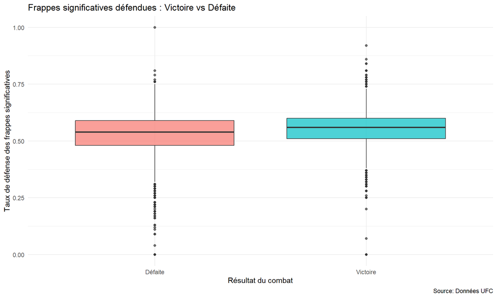

**Interprétation :** Les vainqueurs présentent un taux de défense plus élevé. Une meilleure capacité à éviter les frappes semble être un facteur clé pour gagner, notamment en stand-up.

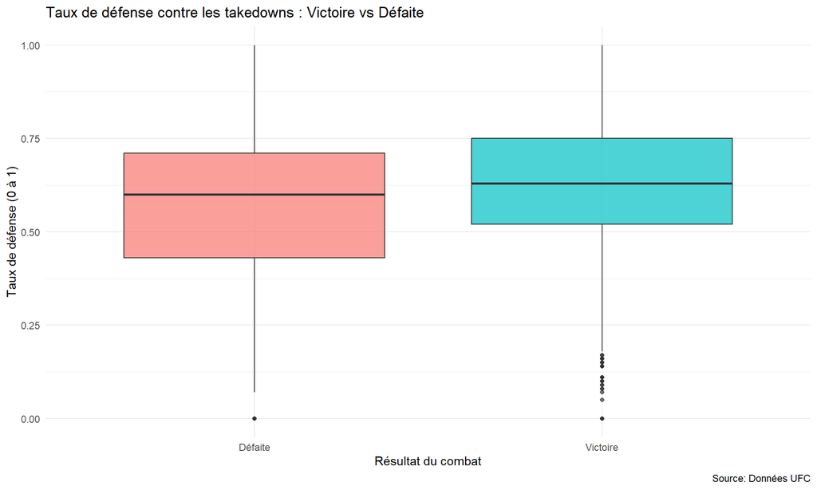

**Interprétation :** Une défense de takedown plus solide est associée à la victoire. Cela montre l’importance de résister aux tentatives de mise au sol, en particulier contre des combattants spécialisés en grappling.

#### Visualisation 3 : Mise en avant des tendances favorisant la victoire

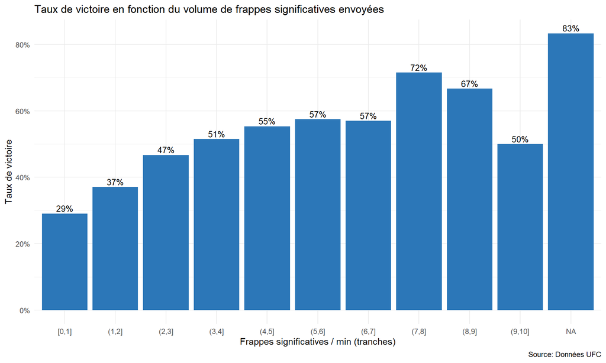

**Interprétation :** Le taux de victoire augmente clairement avec le volume de frappes envoyées. Cela confirme qu’une pression constante et une activité offensive élevée favorisent la victoire.

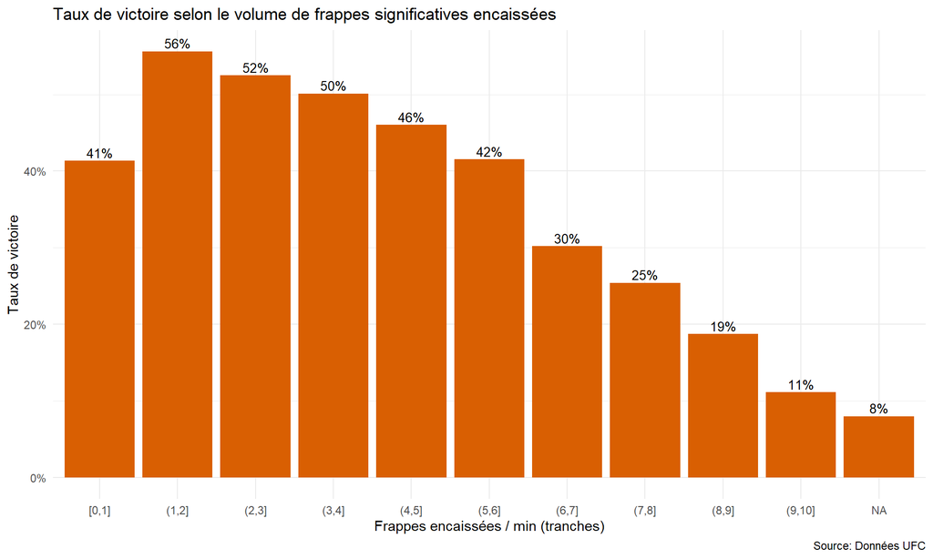

**Interprétation :** Le taux de victoire diminue avec l’augmentation des frappes encaissées. Cela renforce l’idée qu’une bonne défense et un faible nombre de coups reçus sont essentiels pour gagner.

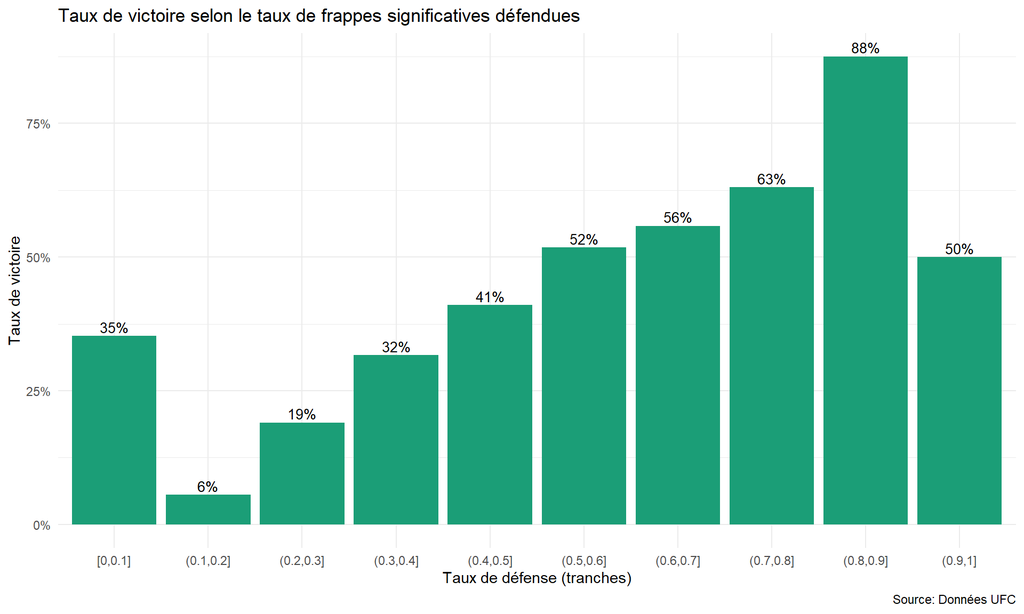

**Interprétation :** Les combattants qui défendent mieux les frappes ont un taux de victoire plus élevé. Cela suggère que l’efficacité défensive, bien que moins visible que l’offensive, est un levier important de performance.

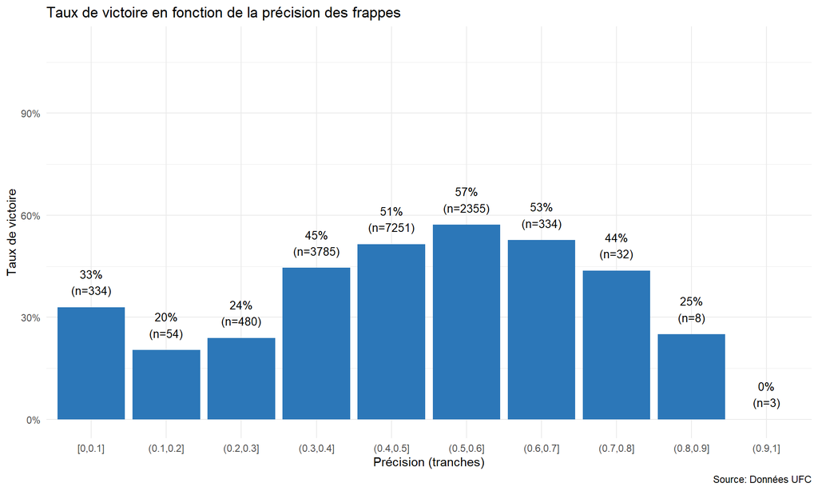

#### Visualisation 4 : Y’a t-il un secteur à privilégier pour espérer gagner

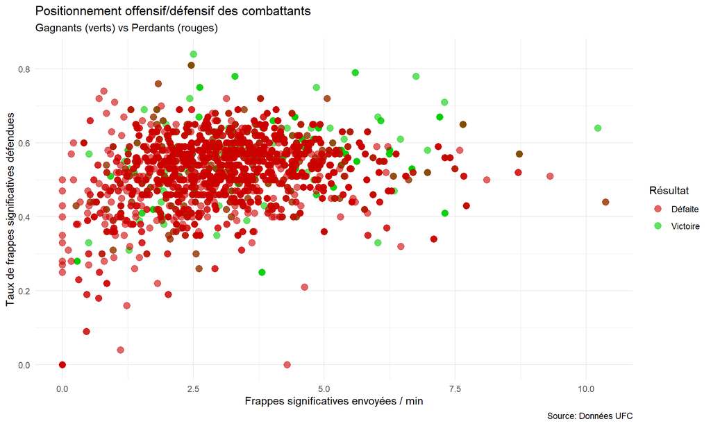

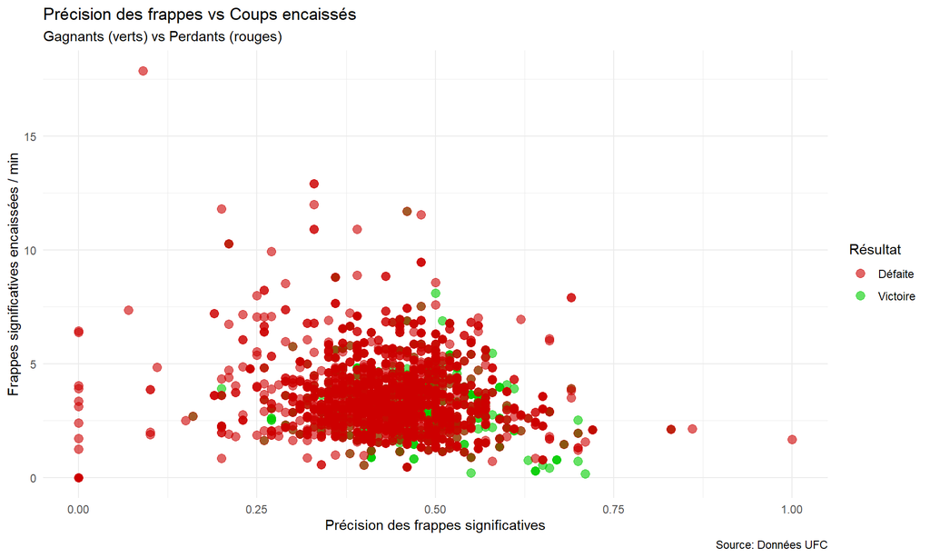

**Interprétation :** Les deux derniers graphiques montrent que les gagnants et les perdants peuvent partager des caractéristiques similaires en matière de volume offensif, de précision ou de défense. Cela signifie qu’un style ou un indicateur isolé ne suffit pas à expliquer le succès. Ce résultat met en évidence la complexité du MMA, où l’issue d’un combat dépend probablement d’un ensemble d’éléments combinés : stratégie, timing, conditions du jour, erreurs adverses, etc.

# III. Conclusion

Ce projet nous a permis d’explorer en détail le monde du MMA à travers les données de l’UFC. En croisant les informations issues des combats et celles des combattants, on a pu dégager plusieurs **tendances** très intéressantes, comme l’évolution du nombre de combats au fil du temps, l’impact de certaines caractéristiques physiques sur les performances ou encore le rôle joué par les cotes de paris.

Cette analyse nous a donc aidés à mieux comprendre les facteurs qui peuvent **influencer les résultats** d’un combat. Même si certains liens étaient attendus, d’autres résultats ont été plus surprenants et ont suscité des discussions enrichissantes au sein du groupe.

Ce travail pose aussi les bases pour aller plus loin : on pourrait approfondir l’analyse des paris sportifs, intégrer d’autres sources de données ou encore mettre l’accent sur l’analyse des combattantes. Pour conclure, c’était un projet riche qui nous a permis de mettre en pratique nos compétences tout en explorant un sujet original et passionnant.

### Organisation du travail

**Romain GOLDENCHTEIN** : questions 4, 6, graphique sur la shiny app et dashboard

**Samy EHSANI** : questions 2 et 5

**Jasser CHATBA** : questions 1, 7 et graphique sur la shiny app

**Mohamed AAZOUZ** : questions 3 et 8